# HW 3: Multivariate regression in MLB

Shane Fuller (discussed with Eli Koester)

Fall 2019

# Preliminary notes for doing HW

1. All files should be knit and compiled using R Markdown. Knit early and often! I do not recommend waiting until the end of the HW to knit.
2. All questions should be answered completely, and, wherever applicable, code should be included.
3. If you work with a partner or group, please write the names of your teammates.
4. Copying and pasting of code is a violation of the Skidmore honor code

# Homework questions

## Part I: Multiple regression and player metrics

Return to the `Lahman` package in R, and we’ll use the `Teams` data frame. Below, we create a variable for the number of singles each team had in a season.

```r
library(tidyverse)
library(Lahman)
Teams_1 <- Teams %>%
  filter(yearID >= 2000) %>%
  mutate(X1B = H - X2B - X3B - HR)
```

## Question 1

Let’s use the `Teams` data set (recall: to load this data set from the Lahman package, run the command `data(Teams)`). Using every season since 2000, fit a multiple regression model of runs (`R`) as a function of singles, doubles, triples, home runs, and walks. Showing the code output is sufficient for this question.

```r
library(broom)
runs_model <- lm(R ~ X1B + X2B + X3B + HR + BB, data = Teams_1)
tidy(runs_model)
```

| term | estimate | std.error | statistic | p.value |
| --- | --- | --- | --- | --- |
| (Intercept) | -470.3457441 | 17.93899701 | -26.21918 | 1.112067e-99 |
| X1B | 0.5460835 | 0.01637114 | 33.35647 | 1.521968e-135 |
| X2B | 0.7657466 | 0.04065732 | 18.83416 | 9.415194e-62 |
| X3B | 1.1853213 | 0.11632525 | 10.18972 | 1.702414e-22 |
| HR | 1.5054413 | 0.03417699 | 44.04838 | 1.033742e-184 |
| BB | 0.3385525 | 0.01614121 | 20.97442 | 1.216401e-72 |

## Question 2

Refer to the fit in question 1. Identify the y-intercept, as well as the slopes for singles, doubles, triples, home runs and walks (do not interpret).

*From the model that was produced, it appears that the function has a y-intercept of -470.346, singles has a slope of 0.546, doubles has a slope of 0.766, triples has a slope of 1.185, home runs has a slope of 1.505, and walks has a slope of 0.339.*

## Question 3

Refer to the fit in question 1. Interpret the slope coefficient estimate for triples.

*For every triple that a team hits, they are expected to gain 1.185 total runs for the season, given that singles, doubles, home runs, and walks are in the model.*

## Question 4

Use the fit in question 1 to generate a set of predicted runs scored for each team in your data set.

What is the correlation between your predicted runs and the number of actual runs?

```r
Teams_1 <- Teams_1 %>% mutate(next_R = -470.346 + 0.546*X1B + 0.766*X2B + 1.185*X3B + 1.505*HR + 0.339*BB)
attach(Teams_1)
cor(next_R,R)
```

```
## [1] 0.9574716
```

```r
detach(Teams_1)
```

*The correlation between predicted runs and the number of actual runs is 0.957.*

## Question 5

Identify the following:

1. The number of runs scored by Anaheim in 2000 (`teamID == "ANA"`)
2. The predicted number of runs scored by Anaheim in 2000, using your model in question 1.

```r
Anaheim_2000 <- filter(Teams_1, yearID == 2000, teamID == "ANA")
Anaheim_2000
```

| yearID | lgID | teamID | franchID | divID | Rank | G | Ghome | W | L | DivWin | WCWin | LgWin | WSWin | R | AB | H | X2B | X3B | HR | BB | SO | SB | CS | HBP | SF | RA | ER | ERA | CG | … |
| --- | --- | --- | --- | --- | --- | --- | --- | --- | --- | --- | --- | --- | --- | --- | --- | --- | --- | --- | --- | --- | --- | --- | --- | --- | --- | --- | --- | --- | --- | --- |
| 2000 | AL | ANA | ANA | W | 3 | 162 | 81 | 82 | 80 | N | N | N | N | 864 | 5628 | 1574 | 309 | 34 | 236 | 608 | 1024 | 93 | 52 | 47 | 43 | 869 | 805 | 5 | 5 | … |

```r
predicted_runs <- -470.346 + 0.546*995 + 0.766*309 + 1.185*34 + 1.505*236 + 0.399*608
predicted_runs
```

```
## [1] 947.68
```

## Question 6

Using `mutate()`, create a new variable for the residual between the observed number of runs for each team and what your model predicted.

Next, answer:

1. Which team-season corresponds to the highest residual?
2. Plot the residuals versus `yearID`: Is there any pattern? Would `yearID` be an appropriate term to add to the model?

```r
Teams_1 <- Teams_1 %>% mutate(resid = runs_model$residuals)
arrange(Teams_1, -resid)
```

| yearID | lgID | teamID | franchID | divID | Rank | G | Ghome | W | L | DivWin | WCWin | LgWin | WSWin | R | AB | H | X2B | X3B | HR | BB | SO | SB | CS | HBP | SF | RA | ER | ERA | CG | … |
| --- | --- | --- | --- | --- | --- | --- | --- | --- | --- | --- | --- | --- | --- | --- | --- | --- | --- | --- | --- | --- | --- | --- | --- | --- | --- | --- | --- | --- | --- | --- |
| 2013 | NL | SLN | STL | C | 1 | 162 | 81 | 97 | 65 | Y | N | Y | N | 783 | 5557 | 1494 | 322 | 20 | 125 | 481 | 1110 | 45 | 22 | 64 | 44 | 596 | 555 | 3.42 | 7 | … |
| 2010 | AL | TBA | TBD | E | 1 | 162 | 81 | 96 | 66 | Y | N | N | N | 802 | 5439 | 1343 | 295 | 37 | 160 | 672 | 1292 | 172 | 47 | 57 | 57 | 649 | 611 | 3.78 | 6 | … |
| 2003 | AL | KCA | KCR | C | 3 | 162 | 80 | 83 | 79 | N | N | N | N | 836 | 5568 | 1526 | 288 | 39 | 162 | 476 | 926 | 120 | 42 | 75 | 57 | 867 | 808 | 5.05 | 7 | … |
| 2000 | NL | COL | COL | W | 4 | 162 | 81 | 82 | 80 | N | N | N | N | 968 | 5660 | 1664 | 320 | 53 | 161 | 601 | 907 | 131 | 61 | 42 | 75 | 897 | 835 | 5.26 | 7 | … |
| 2000 | AL | CHA | CHW | C | 1 | 162 | 81 | 95 | 67 | Y | N | N | N | 978 | 5646 | 1615 | 325 | 33 | 216 | 591 | 960 | 119 | 42 | 53 | 61 | 839 | 751 | 4.66 | 5 | … |
| 2016 | NL | SDN | SDP | W | 5 | 162 | 81 | 68 | 94 | N | N | N | N | 686 | 5419 | 1275 | 257 | 26 | 177 | 449 | 1500 | 125 | 45 | 58 | 36 | 770 | 708 | 4.43 | 1 | … |
| 2017 | AL | TEX | TEX | W | 4 | 162 | 81 | 78 | 84 | N | N | N | N | 799 | 5430 | 1326 | 255 | 21 | 237 | 544 | 1493 | 113 | 44 | 81 | 39 | 816 | 742 | 4.66 | 2 | … |
| 2015 | AL | TOR | TOR | E | 1 | 162 | 81 | 93 | 69 | Y | N | N | N | 891 | 5509 | 1480 | 308 | 17 | 232 | 570 | 1151 | 88 | 23 | 54 | 62 | 670 | 609 | 3.80 | 7 | … |
| 2007 | AL | TEX | TEX | W | 4 | 162 | 81 | 75 | 87 | N | N | N | N | 816 | 5555 | 1460 | 298 | 36 | 179 | 503 | 1224 | 88 | 25 | 56 | 42 | 844 | 755 | 4.75 | 0 | … |
| 2008 | AL | MIN | MIN | C | 2 | 163 | 81 | 88 | 75 | N | N | N | N | 829 | 5641 | 1572 | 298 | 49 | 111 | 529 | 979 | 102 | 42 | 36 | 72 | 745 | 675 | 4.16 | 5 | … |

[output cut: 560 more lines]

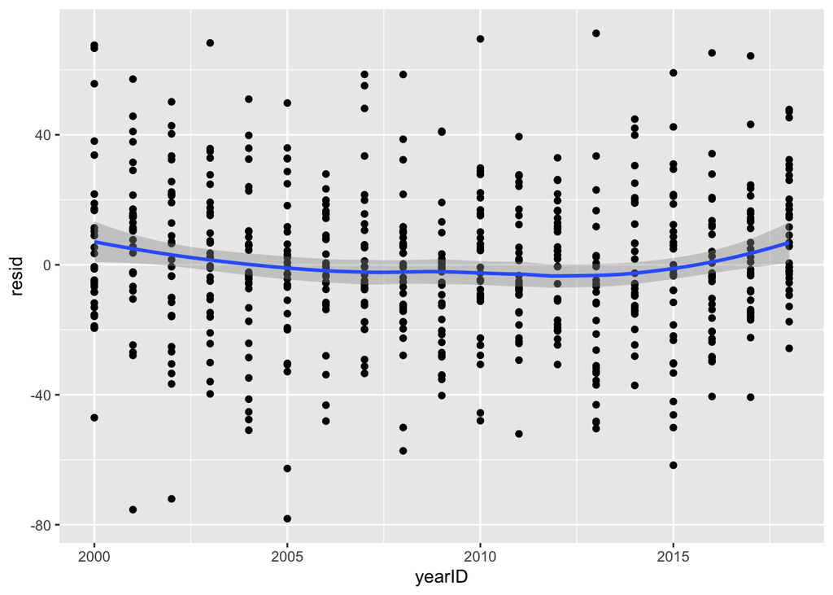

```r
ggplot(data = Teams_1, aes(x = yearID, y = resid)) + geom_point() + geom_smooth()
```

*i) The 2013 St Louis Cardinals had the highest residual with a difference of about 71 runs* *ii) There does not seem to be any consistent pattern in the residuals in relation to the year, as they seem relatively consistent over the past few years. Therefore, yearID would not be an apporopriate term to add to the model, as it doesn’t seem to show any new trends in the data.*

## Question 7

Using the output from Question 1, discuss the relative importance of each type of productive at bat (singles, doubles, triples, home runs, walks) with respect to run generation. Does anything surprise you?

*When discussing relative importance of each type of productive at bats in realtion to run production, the values all seemed to make sense. Walks contributed the least, followed by singles, doubles, triples, and home runs in that relative order. There seemed to be a larger separation between triples and home runs over doubles and below, however this would seem to make sense as it is likely that the more runs will be converted from a triple than a double. Otherwise, each slope seemed to make sense.*

## Question 8

Pick another variable in the `Teams` data set, and add it to your regression model. Interpret it’s slope. Also, does this new variable appear to be significantly associated with runs scored, given the other variables in the model?

```r
new_runs_model <- lm(R ~ X1B + X2B + X3B + HR + BB + SB, data = Teams_1)
tidy(new_runs_model)
```

| term | estimate | std.error | statistic | p.value |
| --- | --- | --- | --- | --- |
| (Intercept) | -477.3314591 | 17.77601632 | -26.852555 | 7.121556e-103 |
| X1B | 0.5363290 | 0.01632246 | 32.858336 | 5.103869e-133 |
| X2B | 0.7894146 | 0.04051676 | 19.483653 | 5.201668e-65 |
| X3B | 1.0942455 | 0.11687500 | 9.362529 | 1.847045e-19 |
| HR | 1.5132831 | 0.03376434 | 44.818977 | 7.397643e-188 |
| BB | 0.3342987 | 0.01595452 | 20.953230 | 1.674702e-72 |
| SB | 0.1407629 | 0.03440566 | 4.091272 | 4.916858e-05 |

*The slope would state that for every base that a team steals, they are expected to gain 0.141 total runs for the season, given that singles, doubles, triples, home runs, and walks are in the model. Regarding its significant association, it appears that stolen bases is relevant, as it has such a low p-value. However, in relation to the other variables, it seems that stolen bases has less of an impact on runs scored.*

# Part II: Model assessment

Several models are proposed.

```r
fit_1 <- lm(R ~ X1B + X2B + X3B + HR, data = Teams_1)
fit_2 <- lm(R ~ X1B + X2B + X3B + HR + BB, data = Teams_1)
fit_3 <- lm(R ~ X1B + X2B + X3B + HR + BB + SO, data = Teams_1)
fit_4 <- lm(R ~ X1B + X2B + X3B + HR + BB + SO + CS, data = Teams_1)
fit_5 <- lm(R ~ X1B + X2B + X3B + HR + BB + SO + CS + lgID, data = Teams_1)
fit_6 <- lm(R ~ X1B + X2B + X3B + HR + BB + SO + CS + lgID + SB, data = Teams_1)

options(scipen=999)
```

Note: The `options(scipen = 999)` command disables R’s scientific notation.

## Question 9

Using the AIC criteria, which of the six models would you recommend for measuring runs scored on a team-wide level? From a baseball perspective, what does your choice suggest about certain measurements as far as their link to runs scored?

```r
AIC(fit_1)
```

```
## [1] 5568.7
```

```r
AIC(fit_2)
```

```
## [1] 5242.027
```

```r
AIC(fit_3)
```

```
## [1] 5236.57
```

```r
AIC(fit_4)
```

```
## [1] 5234.499
```

```r
AIC(fit_5)
```

```
## [1] 5207.98
```

```r
AIC(fit_6)
```

```
## [1] 5200.828
```

## Question 10

One of the coefficients in `fit_5` and `fit_6` is `lgID`. Generate a table of the `lgID` in your data set. What does this variable refer to?

```r
tidy(fit_5)
```

[output not shown]

```r
tidy(fit_6)
```

[output not shown]

*In both models, the AL league is the reference variable. Therefore, this states that if a team is in the NL, they are expected to score about 10 runs less than a team in the AL.*

## Question 11

Using the code below, the coefficient for `league = "NL"` is negative. Interpret this coefficient. What about baseball’s rules make it important to consider which league each team played in? Note: you can google the differences between the American League and the National League to guide you.

```r
library(broom)
tidy(fit_5)
```

[output not shown]